# Titanic_Case Study - EDA

```python
#Import Libraries
import numpy as np
import pandas as pd
import matplotlib.pyplot as plt
import seaborn as sns
%matplotlib inline
```

**Get the Data**

```python
df = pd.read_csv("Titanic Data Set.csv")
```

**Check Head**

```python
df.head()
```

|  | PassengerId | Survived | Pclass | Name | Sex | Age | SibSp | Parch | Ticket | Fare | Cabin | Embarked |
| --- | --- | --- | --- | --- | --- | --- | --- | --- | --- | --- | --- | --- |
| 0 | 1 | 0 | 3 | Braund, Mr. Owen Harris | male | 22.0 | 1 | 0 | A/5 21171 | 7.2500 | NaN | S |
| 1 | 2 | 1 | 1 | Cumings, Mrs. John Bradley (Florence Briggs Th... | female | 38.0 | 1 | 0 | PC 17599 | 71.2833 | C85 | C |
| 2 | 3 | 1 | 3 | Heikkinen, Miss. Laina | female | 26.0 | 0 | 0 | STON/O2. 3101282 | 7.9250 | NaN | S |
| 3 | 4 | 1 | 1 | Futrelle, Mrs. Jacques Heath (Lily May Peel) | female | 35.0 | 1 | 0 | 113803 | 53.1000 | C123 | S |
| 4 | 5 | 0 | 3 | Allen, Mr. William Henry | male | 35.0 | 0 | 0 | 373450 | 8.0500 | NaN | S |

**Check Info**

```python
df.info()
```

```
<class 'pandas.core.frame.DataFrame'>
RangeIndex: 891 entries, 0 to 890
Data columns (total 12 columns):
PassengerId    891 non-null int64
Survived       891 non-null int64
Pclass         891 non-null int64
Name           891 non-null object
Sex            891 non-null object
Age            714 non-null float64
SibSp          891 non-null int64
Parch          891 non-null int64
Ticket         891 non-null object
Fare           891 non-null float64
Cabin          204 non-null object
Embarked       889 non-null object
dtypes: float64(2), int64(5), object(5)
memory usage: 83.7+ KB
```

**Check a few measures of descriptive statistics**

```python
df.describe()
```

|  | PassengerId | Survived | Pclass | Age | SibSp | Parch | Fare |
| --- | --- | --- | --- | --- | --- | --- | --- |
| count | 891.000000 | 891.000000 | 891.000000 | 714.000000 | 891.000000 | 891.000000 | 891.000000 |
| mean | 446.000000 | 0.383838 | 2.308642 | 29.699118 | 0.523008 | 0.381594 | 32.204208 |
| std | 257.353842 | 0.486592 | 0.836071 | 14.526497 | 1.102743 | 0.806057 | 49.693429 |
| min | 1.000000 | 0.000000 | 1.000000 | 0.420000 | 0.000000 | 0.000000 | 0.000000 |
| 25% | 223.500000 | 0.000000 | 2.000000 | 20.125000 | 0.000000 | 0.000000 | 7.910400 |
| 50% | 446.000000 | 0.000000 | 3.000000 | 28.000000 | 0.000000 | 0.000000 | 14.454200 |
| 75% | 668.500000 | 1.000000 | 3.000000 | 38.000000 | 1.000000 | 0.000000 | 31.000000 |
| max | 891.000000 | 1.000000 | 3.000000 | 80.000000 | 8.000000 | 6.000000 | 512.329200 |

**Of all passengers in df, how many survived, how many died ?**

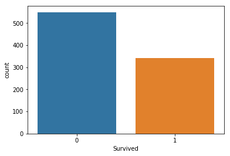

```python
sns.countplot(x='Survived', data=df)
```

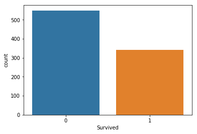

```python
sns.countplot(x='Survived', data=df);
```

Notice the difference between these two plots....

**Check the % of people who have survived.**

```python
print(df.Survived.value_counts(1)[1]*100)
```

```
38.38383838383838
```

**Which Gender survived the crash more?** **Male or Female?**

```python
df.groupby(['Survived','Sex'])['Survived'].count()
```

```
Survived  Sex
0         female     81
          male      468
1         female    233
          male      109
Name: Survived, dtype: int64
```

**Visualize the above numbers**

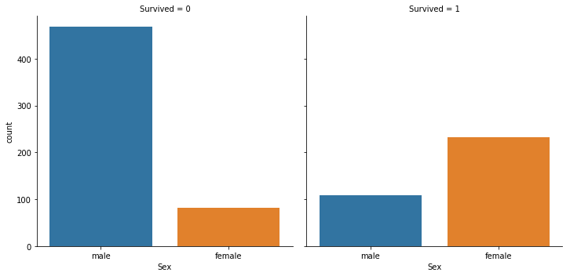

```python
sns.catplot(x='Sex', col='Survived', kind='count', data=df);
```

**The percentage of men and women who survived the crash are?**

```python
print("% of women survived: " , df[df.Sex == 'female'].Survived.value_counts(1)[1]*100)
print("% of men survived:   " , df[df.Sex == 'male'].Survived.value_counts(1)[1]*100)
```

```
% of women survived:  74.20382165605095
% of men survived:    18.890814558058924
```

**Visualize the above % gender wise**

Make pie chart

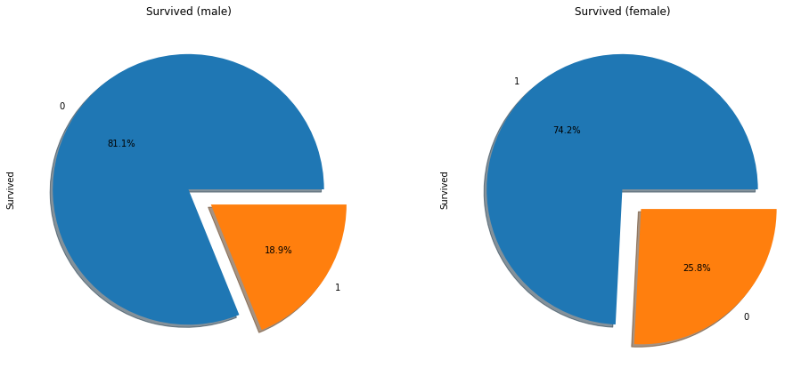

```python
f,ax=plt.subplots(1,2,figsize=(16,7))
df['Survived'][df['Sex']=='male'].value_counts().plot.pie(explode=[0,0.2],autopct='%1.1f%%',ax=ax[0],shadow=True)
df['Survived'][df['Sex']=='female'].value_counts().plot.pie(explode=[0,0.2],autopct='%1.1f%%',ax=ax[1],shadow=True)
ax[0].set_title('Survived (male)')
ax[1].set_title('Survived (female)')

plt.show()
```

**Plot a table of `Pclass` and `Survived` variable**

```python
pd.crosstab(df.Pclass, df.Survived, margins=True).style.background_gradient(cmap='autumn_r')
```

| Survived Pclass | 0 | 1 | All |
| --- | --- | --- | --- |
| 1 | 80 | 136 | 216 |
| 2 | 97 | 87 | 184 |
| 3 | 372 | 119 | 491 |
| All | 549 | 342 | 891 |

**Check the proportion of passengers who survived from different Ticket Classes**

```python
print("% of survivals in")
print("Pclass=1 : ", df.Survived[df.Pclass == 1].sum()/df[df.Pclass == 1].Survived.count())
print("Pclass=2 : ", df.Survived[df.Pclass == 2].sum()/df[df.Pclass == 2].Survived.count())
print("Pclass=3 : ", df.Survived[df.Pclass == 3].sum()/df[df.Pclass == 3].Survived.count())
```

```
% of survivals in
Pclass=1 :  0.6296296296296297
Pclass=2 :  0.47282608695652173
Pclass=3 :  0.24236252545824846
```

**Plot the fraction of passengers survived against their Ticket Class**

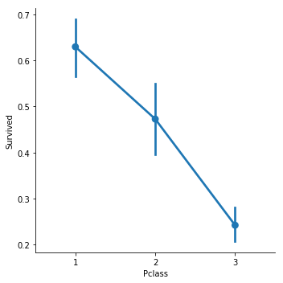

```python
sns.catplot('Pclass','Survived', kind='point', data=df);
```

The above graph has plotted the confidence interval. Let us remove the confidence intervals and try to plot it once more.

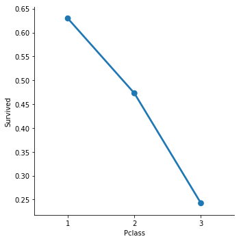

```python
sns.catplot('Pclass','Survived', kind='point', data=df, ci = False);
```

**Plot a table of `Sex`,`Pclass` and `Survived` variable**

```python
pd.crosstab([df.Sex, df.Survived], df.Pclass, margins=True).style.background_gradient(cmap='autumn_r')
```

| Sex | Pclass Survived | 1 | 2 | 3 | All |
| --- | --- | --- | --- | --- | --- |
| female | 0 | 3 | 6 | 72 | 81 |
|  | 1 | 91 | 70 | 72 | 233 |
| male | 0 | 77 | 91 | 300 | 468 |
|  | 1 | 45 | 17 | 47 | 109 |
| All |  | 216 | 184 | 491 | 891 |

**Plot the proportion of people who survived the crash of the ship keeping the gender in mind**

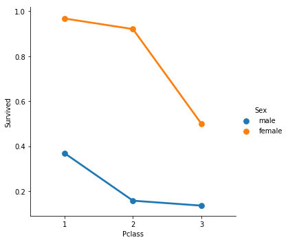

```python
sns.catplot('Pclass','Survived',hue='Sex', kind='point', data=df, ci= False);
```

**Make a countplot for `Survived` and `Embarked` variables**

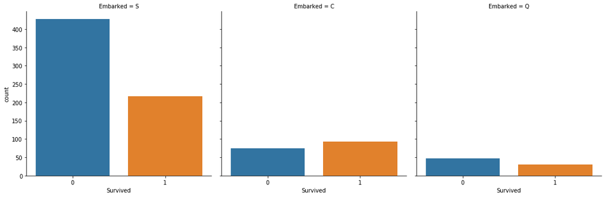

```python
sns.catplot(x='Survived', col='Embarked', kind='count', data=df);
```

**Make a point plot for `Survived` and `Embarked` variables**

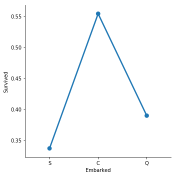

```python
sns.catplot('Embarked','Survived', kind='point', data=df,ci = False);
```

**Make a point plot for `Survived`,`Embarked` and `Sex` variables**

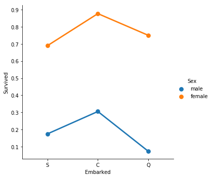

```python
sns.catplot('Embarked','Survived', hue= 'Sex', kind='point', data=df, ci = False);
```

**Make a point plot for `Survived`,`Embarked`,`Sex`, and `Pclass` variables**

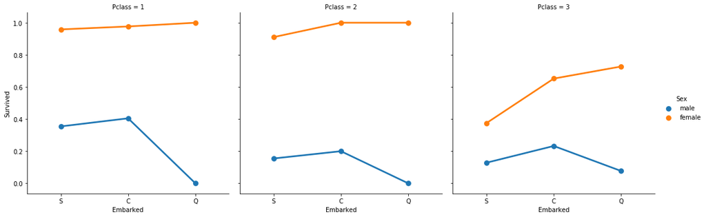

```python
sns.catplot('Embarked','Survived', col='Pclass', hue= 'Sex', kind='point', data=df, ci = False);
```

**Make a table of `Sex`,`Pclass`,`Embarked`,`Survived` variables**

```python
pd.crosstab([df.Survived], [df.Sex, df.Pclass, df.Embarked], margins=True)
```

| Sex Pclass Embarked Survived | female 1 C | female 1 Q | female 1 S | female 2 C | female 2 Q | female 2 S | female 3 C | female 3 Q | female 3 S | male 1 C | male 1 Q | male 1 S | male 2 C | male 2 Q | male 2 S | male 3 C | male 3 Q | male 3 S | All |
| --- | --- | --- | --- | --- | --- | --- | --- | --- | --- | --- | --- | --- | --- | --- | --- | --- | --- | --- | --- |
| 0 | 1 | 0 | 2 | 0 | 0 | 6 | 8 | 9 | 55 | 25 | 1 | 51 | 8 | 1 | 82 | 33 | 36 | 231 | 549 |
| 1 | 42 | 1 | 46 | 7 | 2 | 61 | 15 | 24 | 33 | 17 | 0 | 28 | 2 | 0 | 15 | 10 | 3 | 34 | 340 |
| All | 43 | 1 | 48 | 7 | 2 | 67 | 23 | 33 | 88 | 42 | 1 | 79 | 10 | 1 | 97 | 43 | 39 | 265 | 889 |

**Check the distribution of the fare**

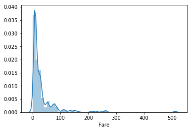

```python
sns.distplot(df['Fare']);
```

**Make the point plot of `Survived`,`Sex`, `Pclass`**

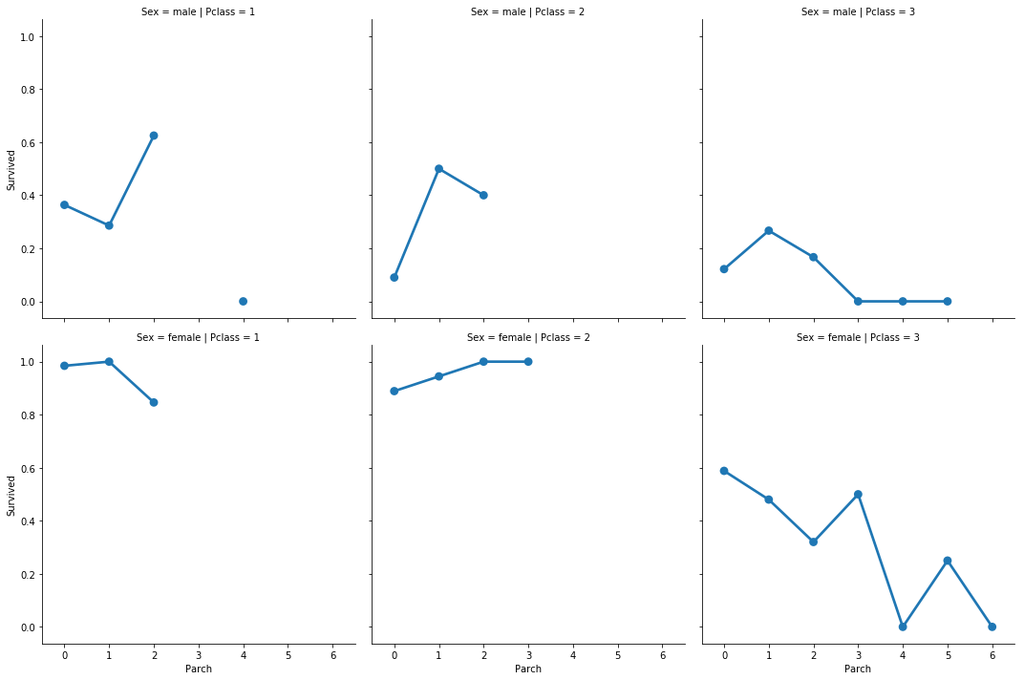

```python
sns.catplot('Parch','Survived', col='Pclass' , row = 'Sex', kind='point', data=df,ci = False);
```

**Plot the proportion of siblings / spouses aboard the Titanic who have survived.**

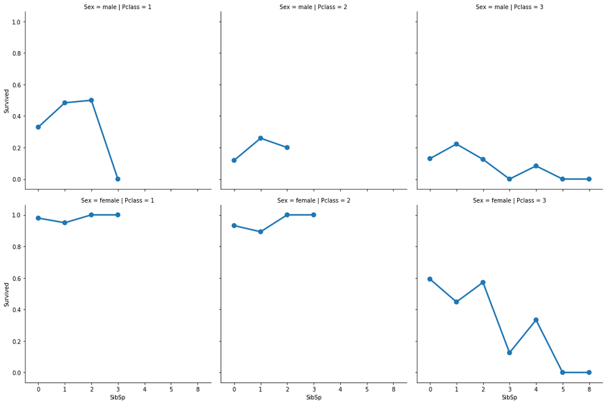

```python
sns.catplot('SibSp','Survived', col='Pclass' , row = 'Sex', kind='point', data=df, ci = False);
```

Let us check the correlation among various values.

**Make the 'heatmap' of Correlation**

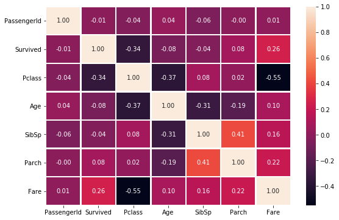

```python
corr = df.corr()

f,ax = plt.subplots(figsize=(9,6))
sns.heatmap(corr, annot = True, linewidths=1.5 , fmt = '.2f',ax=ax)
plt.show()
```

```
                                            Happy Learning
```